# Sentiment Analysis of Persian Comments on an E-commerce Website

In this project we will breakdown and analyse the sentiment of comments on a website where people buy different products and determine whether they are positive or negative.

## Datasets

Two datasets are given in the same folder as this file. One dataset is for training our learning model (comment_train.csv) and one for testing our model (comment_test.csv). Each dataset has three columns: title, comment and recommend. The first two columns (title and comment) are the features of the model and they are used for predicting if the comment is recommending the product.In the training dataset we use all three columns to train our model and in the testing dataset we use the first two columns and predict the last (recommend) column and check whether are predictions are correct.

## Packages

First, let's run the cell below to import all the packages that we will need during this assignment.

- [future](https://pypi.org/project/future/) allows you to use a single, clean Python 3.x-compatible codebase to support both Python 2 and Python 3 with minimal overhead. -hazm is a Python library for digesting Persian text.
- numpy is the fundamental package for scientific computing with Python.
- [pandas](https://pandas.pydata.org) is a fast and easy to use open source data analysis and manipulation tool built on top of Python.
- [collections](https://docs.python.org/3/library/collections.html) implements specialized container datatypes providing alternatives to Python’s general purpose built-in containers, dict, list, set, and tuple.
- [matplotlib](https://matplotlib.org/) is a comprehensive library for creating static, animated, and interactive visualizations in Python.

```python
from __future__ import unicode_literals
from hazm import *
import numpy as np
import pandas as pd
import collections
import matplotlib.pyplot as plt
import plotly.graph_objects as go
```

## Reading the CSV File

Since the titles and the main part of the comments are both important we concatenate the two.

```python
train_dataset = pd.read_csv("sentiment_dataset/comment_train.csv")
test_dataset = pd.read_csv("sentiment_dataset/comment_test.csv")
train_dataset["whole_comment"] = train_dataset["title"] + str(" ") + train_dataset["comment"]
test_dataset["whole_comment"] = test_dataset["title"] + str("") + test_dataset["comment"]
```

## Phase 1: Data Pre-processing

Before analyzing any text dataset it is important to make it more predictable and analyzable.Here are some of the most common text pre-processing methods:

- **Normalizing** is the process of transforming a text into a canonical (standard) form. For example, the word “gooood” and “gud” can be transformed to “good”, its canonical form. In Persian, there can be full and half spaces between the words and in normalization we can replace the full spaces with half spaces if it is necessary.
- **Stemming** is the process of reducing inflection in words (e.g. troubled, troubles) to their root form (e.g. trouble). The “root” in this case may not be a real root word, but just a canonical form of the original word.For example "better" might become "bett" in this case.
- **Lemmatization** on the surface is very similar to stemming, where the goal is to remove inflections and map a word to its root form. The only difference is that, lemmatization tries to do it the proper way.For example "better" is replaced with "good". Using stemming and lemmatization let us find the root of different words and correspond them to the same meaning (and sentiment in this case), instead of having various words with the same meaning.
- **Stop words** are a set of commonly used words in a language. Examples of stop words in English are “a”, “the”, “is”, “are” and etc. The intuition behind using stop words is that, by removing low information words from text, we can focus on the important words instead.
- **Lowercasing** all text data, although commonly overlooked, is one of the simplest and most effective forms of text preprocessing.This form however is not possible with Persian as there is no such thing as lower or upper case letters.

```python
#making different copies of titles and comments to change
normalizer = Normalizer()
stemmer = Stemmer()
lemmatizer = Lemmatizer()

final_train = train_dataset[["whole_comment","recommend"]].copy()
final_test = test_dataset[["whole_comment","recommend"]].copy()
train_length = len(train_dataset) #number of training comments
test_length = len(test_dataset) #number of testing comments
def reset_datasets():
    final_train = train_dataset[["whole_comment","recommend"]].copy()
    final_test = test_dataset[["whole_comment","recommend"]].copy()
    train_length = len(train_dataset) #number of training comments
    test_length = len(test_dataset) #number of testing comments

def apply_normalizations():
    #for word in stopwords_list():
     #   final_train["whole_comment"] = final_train["whole_comment"].str.replace(word,'')
      #  final_test["whole_comment"] = final_test["whole_comment"].str.replace(word,'')

    for index in range(train_length):
        this_comment = str(train_dataset.loc[index,"whole_comment"])
        final_train.loc[index,"whole_comment"] = normalizer.normalize(this_comment)
        final_train.loc[index,"whole_comment"] = stemmer.stem(final_train.loc[index,"whole_comment"])
        final_train.loc[index,"whole_comment"] = lemmatizer.lemmatize(final_train.loc[index,"whole_comment"])
        #final_train.loc[index,"whole_comment"] = sent_tokenize(this_comment)
        #final_train.loc[index,"whole_comment"] = word_tokenize(this_comment)

        #final_train.loc[index, "whole_comment"] = tagger.tag(word_tokenize(final_train.loc[index, "whole_comment"]))


    for index in range(test_length):
        this_comment = str(test_dataset.loc[index,"whole_comment"])
        final_test.loc[index,"whole_comment"] = lemmatizer.lemmatize(final_test.loc[index,"whole_comment"])
        final_test.loc[index,"whole_comment"] = normalizer.normalize(this_comment)
        final_test.loc[index,"whole_comment"] = stemmer.stem(final_test.loc[index,"whole_comment"])
        #final_test.loc[index,"whole_comment"] = sent_tokenize(this_comment)
        #final_test.loc[index,"whole_comment"] = word_tokenize(this_comment)

        #final_test.loc[index, "whole_comment"] = tagger.tag(word_tokenize(final_test.loc[index, "whole_comment"]))
```

## Phase 2: The Problem Process

As the name of the program suggets we want to use naive bayes classifier to classify the comments into recommended and not recommended categories.We will use the **bag of words** model which means we consider every word in the dataset separately regardless of its' location in the comments and count the number of its' occurances in the dataset.Based on **naive bayes** we have:
$$ P(recommend|comment) = \frac{P(comment|recommend)P(recommend)}{P(comment)} $$

$$ P(recommend|comment) \alpha P(comment|recommend)P(recommend) $$

$$ P(comment|recommend)P(recommend) = P(recommend) \prod_{i=1}^{n} P(word_i|recommend) $$

### Training the Model

Using the training dataset we calculate $ P(recommend) $ and $ P(word|recommend) $ for every word. To calculate each one of them respectively we have to do the follwoing processes in the train_comment dataset:

- $$ P(recommend) = \frac{total \: number \: of \: recommendations}{total \: number \: of \: comments} $$
  $$ n_{recommend} = total \: number \: of \: recommendations \: of \: word_i $$
  $$ N_{total} = total \: number \: of \: occurrences \: of \: word_i $$
- $$ P(word_i|recommend) = \frac{n_{recommend}}{N_{total}} $$

The same values can be calculated for not_recommended rows.Once we have all these probabilities, using the naive bayes formulation given above, we compare $ P(comment|recommend) $ and $ P(comment|not \space recommend)$ and if one of them is biggr than the other one, we can conclude whether the comment is recommending the product in the testing dataset.

```python
p_recommend = (final_train[["recommend"]].values=='recommended').sum() / train_length
p_not_recommend = (final_train[["recommend"]].values=='not_recommended').sum() / train_length

#making the bag of words
ignore = {'recommended','not_recommended'}
train_counter = collections.Counter([y for x in final_train.values.flatten() for y in x.split() if y not in ignore])

#counting the words in the recommended comments
final_train_recommended = final_train[final_train.recommend == "recommended"] #separating recommended rows
final_recommended_counter = collections.Counter([y for x in final_train_recommended.values.flatten() for y in x.split() if y not in ignore])

#counting the words in the not_recommended comments
final_train_not_recommended = final_train[final_train.recommend == "not_recommended"] #separating not_recommended rows
final_not_recommended_counter = collections.Counter([y for x in final_train_not_recommended.values.flatten() for y in x.split() if y not in ignore])

#setting the conditional probabilities to total word count and changing them in the future
global p_word_recommend
global p_word_not_recommend
p_word_recommend = dict(final_recommended_counter)
p_word_not_recommend = dict(final_not_recommended_counter)

def reset_probabilities(): #resetting them when needed
    #making the bag of words
    ignore = {'recommended','not_recommended'}
    train_counter = collections.Counter([y for x in final_train.values.flatten() for y in x.split() if y not in ignore])
    global unique_words
    unique_words = set(train_counter)

    #counting the words in the recommended comments
    final_train_recommended = final_train[final_train.recommend == "recommended"] #separating recommended rows
    final_recommended_counter = collections.Counter([y for x in final_train_recommended.values.flatten() for y in x.split() if y not in ignore])

    #counting the words in the not_recommended comments
    final_train_not_recommended = final_train[final_train.recommend == "not_recommended"] #separating not_recommended rows
    final_not_recommended_counter = collections.Counter([y for x in final_train_not_recommended.values.flatten() for y in x.split() if y not in ignore])

    #setting the conditional probabilities to total word count and changing them in the future
    p_word_recommend = dict(final_recommended_counter)
    p_word_not_recommend = dict(final_not_recommended_counter)
```

### Additive Smoothing

Some words may appear in the train dataset but not in the testing dataset, also some words may appear in the recommended class more often in the training dataset and less often in the testing dataset.
In statistics, additive smoothing, also called Laplace smoothing or Lidstone smoothing, is a technique used to smooth categorical data. Which in this case can solve our data distribution as there might be uncontinuities or critical points in the data probability distribution.
From a Bayesian point of view, this corresponds to the expected value of the posterior distribution, using a symmetric Dirichlet distribution with parameter α as a prior distribution. Here the number of categories is 2, this is equivalent to using a Beta distribution as the conjugate prior for the parameters of Binomial distribution.
Previously we ignored the words that did not exist, but this time we use their actual probability (zero) and use additive smoothing.Meaning we will use:
$$ P(word_i|recommend) = \frac{n_{recommend + \alpha }}{N_{total + \alpha d}} $$ The same procedure can be used for $ P(word_i| not \space recommend) $ .
The values of $\alpha$ and $d$ can be trained but they are usually set to 1 and 14 respectively.
We make a dictionary of all the words in whole_comment column and calculate the probability of them being recommended or not recommended in p_word_recommend and p_word_not_recommend using additive smoothing.

```python
def train_probabilities(alpha, d): #applies no additive smoothing if alpha and d are 0
    global p_word_recommend
    global p_word_not_recommend
    for line in range(len(final_test)):
        unique_words.update(str(final_test.loc[line,"whole_comment"]).split())
    for word in unique_words:
        global p_word_recommend
        global p_word_not_recommend
        if word in p_word_recommend:
            p_word_recommend[word] = (p_word_recommend[word] + alpha)/(train_counter[word] + alpha*d)
        else:
            p_word_recommend[word] = (alpha)/(train_counter[word] + alpha*d)

        if word in p_word_not_recommend:
            p_word_not_recommend[word] = (p_word_not_recommend[word]+alpha)/(train_counter[word]+alpha*d)
        else:
            p_word_not_recommend[word] = (alpha)/(train_counter[word]+alpha*d)
```

### Testing the Model

Since $$ P(recommend|comment) \alpha P(comment|recommend)P(recommend) $$
and we have calculated both $P(word|recommend)$ and $P(recommend) $ in the training process, we calculate $ P(comment|recommend)P(recommend) $ for each whole comment by: $$ P(comment|recommend)P(recommend) = P(recommend) \prod_{i=1}^{n} P(word_i|recommend) $$
If $ P(recommend|comment) > P(not \space recommend|comment) $ we conclude that the comment is recommending the product and not recommending otherwise.

```python
def test_the_model():
    #predictions will multiply 1 and change the initial value
    final_test["recommend_prediction"] = 1
    final_test["not_recommend_prediction"] = 1
    final_test["final_prediction"] = "recommended"
    for line in range(test_length):
        this_comment = str(final_test.loc[line,"whole_comment"]).split()
        for word in this_comment:
            final_test.loc[line,"recommend_prediction"] *= p_word_recommend[word]
            final_test.loc[line,"not_recommend_prediction"] *= p_word_not_recommend[word]
        final_test.loc[line,"recommend_prediction"] *= p_recommend
        final_test.loc[line,"not_recommend_prediction"] *= p_recommend
        if final_test.loc[line,"recommend_prediction"] > final_test.loc[line,"not_recommend_prediction"]:
            final_test.loc[line,"final_prediction"] = "recommended"
        else:
            final_test.loc[line,"final_prediction"] = "not_recommended"
```

## Phase 3: Evaluation

To evaluate our model we calculate four criteria:
$$ Accuracy = \frac{correct \space detected}{total} $$
$$ Precision = \frac{correct \space detected \space recommended}{all \space detected \space recommended(including \space wrong \space ones)} $$
$$ Recall = \frac{correct\space detected \space recommended}{total \space recommended} $$
$$ F1 = 2 x \frac{Precision*Recall}{Precision+Recall} $$

- **Correct Detected Recommended**: the number of comments that have been predicted to be recommended correctly.
- **All Detected Recommended** : the total number of comments that have been predicted to be recommended.
- **Total Recommended** : all the comments that are recommended in the test dataset.

Why are **precision** and **recall** not enough to evaluate the model individually?  
Precision shows how many of our recommended predictions are correct.If we only consider precision, all the comments we predicted to be recommendations could be correct while having predicted a lot of other comments that are recommendations as not_recommended.Therefore, our model could be not efficient.  
On the other hand, since recall demonstrates how many of the actual recommendations we have predicted correctly, it could have a high value while predicting many not_recommended comments to be recommended.In this case, our model would still not be efficient enough.  
Therefore, it is necessary to consider both of these criteria.

What type of mean is **F1** ? How effective is it?  
F1 is the harmonic mean o f precision and recall.Harmonic mean is in fact the reciprocal of the mean of reciprocals.Harmonic means are useful when two or more values are effective in the problem.Here, precision and recall are both important criteria and we want both of them to be as high as possible.Therefore, we will be using F1-score (criterion).

```python
def evaluate_model(): # returns accuracy, precision, recall and f1-score
    correct_detected = 0
    correct_detected_recommended = 0
    all_detected_recommended = 0
    total_recommended = 0
    total = test_length
    for line in range(test_length):
        if final_test.loc[line, "recommend"] == final_test.loc[line, "final_prediction"]:
            correct_detected += 1
            if final_test.loc[line, "final_prediction"] == "recommended":
                correct_detected_recommended += 1
        if final_test.loc[line, "recommend"] == "recommended":
            total_recommended += 1
        if final_test.loc[line, "final_prediction"] == "recommended":
            all_detected_recommended += 1
    accuracy = correct_detected/total
    precision = correct_detected_recommended/all_detected_recommended
    recall = correct_detected_recommended/total_recommended
    f1 = 2*(precision*recall)/(precision+recall)
    return accuracy, precision, recall, f1
```

## Final Evaluation and Comparisons

### 1) Adding Preprocessings and Additive Smoothing

```
Accuracy 0.8775 Precision 0.8185654008438819 Recall 0.97 F1 0.8878718535469108
```

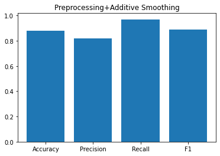

```python
reset_datasets()
apply_normalizations() #adding the normalizations
reset_probabilities()
train_probabilities(1,14) #adding additive smoothing
test_the_model()
accuracy1, precision1, recall1, f1_1 = evaluate_model()
y1 = [accuracy1, precision1, recall1, f1_1]
print("Accuracy", accuracy1, "Precision", precision1, "Recall", recall1, "F1", f1_1)

#plotting
x1 = np.array([1,2,3,4])
names = ["Accuracy", "Precision", "Recall", "F1"]
plt.bar(x1,y1,tick_label=names)
plt.title("Preprocessing+Additive Smoothing")
```

### 2) Only Adding Additive Smoothing

```
Accuracy 0.8275 Precision 0.7673469387755102 Recall 0.94 F1 0.8449438202247191
```

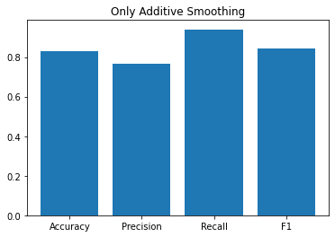

```python
reset_datasets()
reset_probabilities()
train_probabilities(1,14) #adding additive smoothing
test_the_model()
accuracy2, precision2, recall2, f1_2 = evaluate_model()
y2 = [accuracy2, precision2, recall2, f1_2]
print("Accuracy", accuracy2, "Precision", precision2, "Recall", recall2, "F1", f1_2)

#plotting
x2 = np.array([1,2,3,4])
names = ["Accuracy", "Precision", "Recall", "F1"]
plt.bar(x2,y2,tick_label=names)
plt.title("Only Additive Smoothing")
```

### 3) Only Adding Preprocessing

[output not shown]

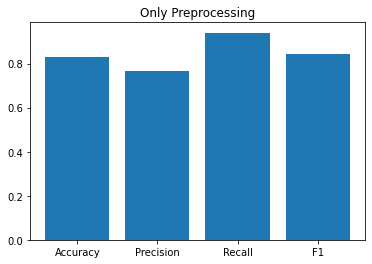

```python
reset_datasets()
apply_normalizations() #adding the normalizations
reset_probabilities()
test_the_model()
accuracy3, precision3, recall3, f1_3 = evaluate_model()
y3 = [accuracy3, precision3, recall3, f1_3]
print("Accuracy", accuracy1, "Precision", precision1, "Recall", recall1, "F1", f1_1)

#plotting
x3 = np.array([1,2,3,4])
names = ["Accuracy", "Precision", "Recall", "F1"]
plt.bar(x3,y3,tick_label=names)
plt.title("Only Preprocessing")
```

### 4) No Preprocessing or Additive Smoothing

```
Accuracy 0.8275 Precision 0.7673469387755102 Recall 0.94 F1 0.8449438202247191
```

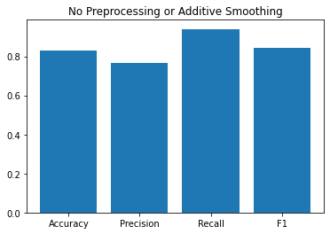

```python
reset_datasets()
reset_probabilities()
test_the_model()
accuracy4, precision4, recall4, f1_4 = evaluate_model()
y4 = [accuracy4, precision4, recall4, f1_4]
print("Accuracy", accuracy4, "Precision", precision4, "Recall", recall4, "F1", f1_4)

#plotting
x4 = np.array([1,2,3,4])
names = ["Accuracy", "Precision", "Recall", "F1"]
plt.bar(x4,y4,tick_label=names)
plt.title("No Preprocessing or Additive Smoothing")
```

### Comparing Results

We draw a table to have a better comparison of the results

```python
fig = go.Figure(data=[go.Table(header=dict(values=['Criteria','Preprocessing+Additive Smoothing'
                                                   ,'Only Additive Smoothing','Only Preprocessing'
                                                   ,'No Preprocessing or Additive Smoothing']),
                 cells=dict(values=[names,y1,y2,y3,y4]))
                     ])
fig.show()
```

[interactive chart not shown]

### Considering the false predictions in preprocessing + additive smoothing and possible solutions

```python
reset_datasets()
apply_normalizations() #adding the normalizations
reset_probabilities()
train_probabilities(1,14) #adding additive smoothing
test_the_model()
counter = 5
for line in range(test_length):
        if final_test.loc[line, "recommend"] != final_test.loc[line, "final_prediction"]:
            print(counter)
            counter -= 1
            print(final_test.loc[line])
        if counter < 0:
            break
```

```
5
whole_comment               وری گودتازه خریدم یه مدت کار بکنه مشخص میشه کی...
recommend                                                         recommended
recommend_prediction                                              2.54956e-25
not_recommend_prediction                                          2.55581e-25
final_prediction                                              not_recommended
Name: 0, dtype: object
4
whole_comment               نقد پس از خریدسلام، راحت شدم از کابل شارژ، توص...
recommend                                                         recommended
recommend_prediction                                              6.61986e-51
not_recommend_prediction                                          6.68914e-51
final_prediction                                              not_recommended
Name: 8, dtype: object
3
whole_comment               ریش تراش نامناسبمن وقتی میخواستم خرید کنم نظرا...
recommend                                                     not_recommended
recommend_prediction                                              3.68816e-58
not_recommend_prediction                                          3.65446e-58
final_prediction                                                  recommended
Name: 9, dtype: object
2
whole_comment               گزینه خوبیهسلام، گزینه خوبیه من یه mg۲۵۴۰ خرید...
recommend                                                         recommended
recommend_prediction                                                        0
not_recommend_prediction                                                    0
final_prediction                                              not_recommended
Name: 15, dtype: object
1
whole_comment               خیالم راحت شدفندک قبلیم مدام فیوز میسوزوند و ی...
recommend                                                         recommended
recommend_prediction                                              2.51965e-71
not_recommend_prediction                                          2.57606e-71
final_prediction                                              not_recommended
Name: 19, dtype: object
0
whole_comment               کت مناسببرای پسرم تهیه کردم خیلی قشنگه دوخت عا...
recommend                                                         recommended
recommend_prediction                                               1.5688e-47
not_recommend_prediction                                          1.57498e-47
final_prediction                                              not_recommended
Name: 27, dtype: object
```

A common problem seems to be in the words that should be separated but are considered to be a single word.To solve this problem we could do other preprocessing methods, for example tokenizing and part-of-speeach tagging) or another method where would could have a dictionary of all the possible words and add space where it is necessary.  
Another problem seems to be the words that do not have any many and are mistakes in typing.To solve this problem, we could still have a dictionary of the possible meaningful words and omit the words that are not in the dictionary.